# R 101

## Introduction

## Introduction

In the last session we covered an introduction to R, reading data in, basic checks and summaries on your data and some of the terminology that will be helpful for the next couple of sessions.

Today we'll be going a bit deeper and looking at data manipulation and aggregation. We're going to focus heavily on the [dplyr](https://cran.rstudio.com/web/packages/dplyr/vignettes/introduction.html) package and get in to some of the gritty realities of working with data.

### Today's data:

- **Oyster**: https://db.tt/81Xpi0LD
- **Stations**: https://db.tt/81Xpi0LD

## A quick look at the data - again

Let's just re-familiarise ourselves with the data again.

| date | start.time | end.time | journey.action | charge | credit | balance | note |
| --- | --- | --- | --- | --- | --- | --- | --- |
| 13-Jan-2016 | 16:49 | 17:23 | South Kensington to Richmond | 3.9 | NA | 9.5 | NA |
| 13-Jan-2016 | 12:27 | 12:57 | Richmond to South Kensington | 2.8 | NA | 13.4 | NA |
| 11-Jan-2016 | 16:49 | 17:32 | South Kensington to Richmond | 3.9 | NA | 16.2 | NA |
| 11-Jan-2016 | 12:49 | 13:18 | Richmond to South Kensington | 2.8 | NA | 20.1 | NA |
| 11-Jan-2016 | 12:49 | NA | Topped up, | NA | 20 | 22.9 | NA |

## A quick look at the data - again

| station | long | lat |
| --- | --- | --- |
| Bank | -0.08800 | 51.51300 |
| Canary Wharf | -0.01861 | 51.50361 |
| Richmond | -0.30140 | 51.46300 |
| South Kensington | -0.17380 | 51.49410 |
| Whitechapel | -0.06100 | 51.51900 |

## Some questions to ask of the data

Now we've seen the data, we can start to come up with some exploratory questions we might ask:

- What are the top 5 journeys?
- What was the longest journey, how long was it, and when was it?
- What is the average journey time for each day of the week?
- What is the average number of journeys per day of the week?
- Where does Jim live, and what are the coordinates of the station?

## A reminder

### and three notes

## A reminder - packages

Packages are great extentions to the `R` language. Packages can be installed using:

```r
install.packages("[package name here]")
```

When you need to *use* a package, you can load it using:

```r
library([package name here])
```

The script file should ensure you have all the packages we need installed and loaded, but if you're unsure please double check.

## A note - your working directory

Your *working directory* is the location on your computer that `R` is "pointing at".

You can find your current working directory using:

```r
getwd()
```

You can then *set* your working directory to somewhere else using:

```r
setwd("PATH/TO/WHERE/YOU/WANT/TO/SET/YOUR/DIRECTORY")
```

## Another note - saving your progress

Another way to save your progress is to save your entire workspace to a file.

This is done using:

```r
save.image(file = "name_of_file.RData")
```

You can then re-load your workspace at any time using:

```r
load(file = "name_of_file.Rdata")
```

This is not necessarily recommended, as it can allow errors to propogate. Scripts are a better way to save your progress.

## The last note - Projects

RStudio projects are a great way to organise your work.

They can be created easily by clicking the drop down in the top right of your RStudio window and selecting "New project".

When you shut a project, anything you were working on will get re-opened the next time you open the project, and your working directory will automatically get set to wherever the project is saved.

## Digging Deepe-R

### Manipulating and aggregating data

## Pro-tip - piping your operations

Before we get in to the details of data manipulation and aggregation, there's an important point we'd like to make about a fantastic new-ish feature in R: the `%>%` pipe.

Taken from the [magrittr](http://cran.r-project.org/web/packages/magrittr/vignettes/magrittr.html) package and popularised in `dplyr`, you can read the `%>%` pipe as "then". The code:

```r
library(magrittr)
some_data %>% some_function
```

can be read as "take some_data, **then** perform some function on it".

## Pro-tip - piping your operations

To get specific, the left hand side of `%>%` is *piped* into the first argument of the function on the right hand side.

There are a few restrictions on exactly what you can *pipe* in to what, but for our purposes this is a good rule of thumb.

You can insert them in to your code with shortcut `CTRL+SHIFT+M` (Windows) or `CMD+SHFT+M` (Mac).

## Pipes in action

Here's a quick example of how a data *pipeline* can work:

```r
 read_csv('/path/to/data/file.csv') %>%
  subset(variable_a > x) %>%
  transform(variable_c = variable_a/variable_b) %>%
  head(100)
```

Note that this is *psuedo-code*: it's just an example!

## dplyr - A very brief introduction

The `dplyr` package is a new(ish) package that aims to make data manipulation easier, more consistent and faster.

It is focused exclusively on data frames and works very well with the pipe paradigm.

It uses a small number of easy to learn functions ("verbs") for the vast majority of operations.

Generally each function takes a data frame as its first argument, and returns a data frame back to you.

## dplyr - Selecting and dropping variables

The simplest dplyr "verb" is `select`, used to select columns in a data frame.

```r
select([data], [fields to select]) # The general form of the function
oyster %>% select(Date, journey.action, charge) # Select just date, journey and charge
oyster %>% select(1, 2, 3) # We can also use column positions to select
oyster %>% select(1:3, 5, 7)
```

We can combine also use "negative selection" to drop variables we don't want any more

```r
oyster %>% select(-journey.action, -charge)
oyster %>% select(-c(4, 6, 7))
```

This can be used to just grab what is needed, or to reorder columns in the data.

## dplyr - Filtering

The second verb is `filter`. We say that `filter` subsets by rows (whereas `select` subsets by columns):

```r
filter([data], [filter conditions]) # the general form of the function

oyster %>% filter(charge != 0) # Numeric condition

oyster %>% filter(note != "") # Text condition
```

To combine multiple filters use `&` for `AND` and `|` for `OR`.

```r
whoops <- oyster %>% filter(balance < 0) # filtering with assignment
noteworthy <- oyster %>% filter(note != "" & charge >= 2) # multiple conditions
```

## dplyr - Filtering (code)

Pretty much any logical test can be used with `filter`, including:

- `>` greater than
- `<` less than
- `==` equal to
- `>=` greater than or equal to
- `<=` less than or equal to
- `between`

## dplyr - Simple aggregations

The `summarise` verb is a powerful way to compute summaries over the data:

```r
summarise([data], [new_field] = some_function([existing_field])) # the general function

oyster %>% summarise(avg_charge = mean(charge, na.rm = TRUE)) # average charge
```

Note that multiple summaries using multiple functions within `summarise`, they just need to be separated by a comma:

```r
oyster %>% summarise(avg_charge = mean(charge, na.rm = TRUE), # average charge
                      sd_charge = sd(charge, na.rm = TRUE)) # charge std. deviation
```

Most functions can be applied within summarise (including bespoke ones!). However, we're probably more interested in grouping our data first.

## Group By - A quick overview

When we compute summaries, we usually more interested in knowing summaries by groups, e.g. males and females, children vs. teenagers vs. adults, ethnic groups etc.

To do this we could manually break our data in to smaller sets and compute the summary or just use a `group by` statement, which effectively does it for us.

If anyone is familiar with pivot tables in Excel, group by is very similar.

## dplyr - Aggregating by groups (code)

`dplyr` has a `group_by` verb that we can add to the chain of commands. Note that we need to group before we summarise.

(Note that `%>%` pipes flow over multiple lines.)

```r
group_by([data], [field_to_group_by_1], [field_to_group_by_2]) # general form

oyster %>% group_by(journey.action) # this doesn't tell us much - add a summary!

oyster %>%
    group_by(journey.action) %>%
    summarise(avg_cost = mean(charge, na.rm = TRUE)) # more interesting
```

## dplyr - Arranging data

Finally, something that is often useful is the `arrange` verb, which sorts/orders data.

```r
arrange([data], [fields_to_order_by]) # general form
oyster %>% arrange(date)
```

It is possible to use a `desc()` to do reverse ordering:

```r
oyster %>% arrange(desc(date))
```

And specify multiple ordering fields:

```r
oyster %>% arrange(journey.action, desc(charge))
```

## dplyr - Putting it all together

Now we've seen the individual functions, we can use the `%>%` operator to create a whole set of instructions to answer our questions, e.g.

> What are the top 5 journeys?

```r
oyster_summary <- oyster %>%
                  group_by(journey.action) %>%
                  summarise(journeys = n()) %>%
                  ungroup() %>%
                  arrange(-journeys) %>%
                  head(5)
```

## The output

| journey.action | journeys |
| --- | --- |
| Richmond to Canary Wharf [London Underground] | 110 |
| Canary Wharf [London Underground] to Richmond | 84 |
| Richmond to Aldgate East | 51 |
| Season ticket bought | 43 |
| South Kensington to Richmond | 42 |

## dplyr - So many options!

`dplyr` is a fantastic package that makes data manipulation incredibly easy. We've so far covered some of the most basic but most used functions.

For a complete set, along with examples, be sure to check out the [cheatsheet](http://www.rstudio.com/wp-content/uploads/2015/01/data-wrangling-cheatsheet.pdf) the author has released.

## Doing Mo-R-e

### Removing mess, adding variables, and further cleaning

## Working with mess

A closer inspection of the data will reveal the presence of fake "journeys" as well as journeys that will not be informative. Some examples include:

- "Topped-up"
- "Season ticket bought"
- "Unspecified location"

This sort of thing is no good, so we'll remove it.

(Note there are other "bad records" in the data, see if you can find them.)

## Slicing and dicing

`dplyr` also provides a handy verb, `slice` that allows rows to be filtered by index, a bit like using the `data[row, column]` syntax but more useful in pipelines.

To start with, though, we need the rows that contain the messy data:

```r
badRecords <- "Topped-up|Season ticket|Unspecified location"
```

## Finding the mess

```r
# grep([what to search], [where to search for it])
records <- grep(badRecords, oyster$journey.action)
```

`grep` is an R function that mimics functionality from the Unix command line, it searches for patterns called **regular expressions**.

Don't worry too much about regular expressions for now, they're just a compact way of specifying patterns to search for. We'll see some other examples later.

## Slicing and dicing (code)

Now that we have our index of bad records, we can use `slice` and `"-"` to get rid of the mess:

```r
# slice([data], [rows to keep or exclude]) the general form
oyster <- oyster %>% slice(-records)
```

Note the use of `-` to do "negative selection" to omit records from the data.

This is similar to using `oyster[-records, ]` but fits in to a `dplyr` pipeline.

However, there's still a lot of mess - poorly formatted dates and useless journey strings.

## dplyr - Adding variables

With dplyr we can add variables to a data set using the `mutate` verb.

```r
mutate([data], [some_new_field]) # general form
oyster %>%  mutate(newField = 4) # set up a new field with the value 4 (always) - useless
```

We can also use simple functions to do calculations, and specify multiple new fields by separating them with commas.

```r
oyster %>% mutate(cost_plus_bal = charge + balance, # add charge to balance
                  cost_plus_bal_clean = sum(charge, balance, na.rm = TRUE)) # clean up
```

Or, use conditions to create variables (similar to an `IF` statement in Excel):

```r
oyster %>% mutate(no_cost = ifelse(charge == 0 | is.na(charge), 1, 0))
```

## dplyr - Adding variables

Now we've seen how 'mutate' works, we can use it to clean up our data a bit. Let's start with the poorly formatted times that we've been provided with.

| start.time | end.time |
| --- | --- |
| 21:43 | 22:12 |
| 18:18 | 18:47 |
| 07:14 | 08:03 |

Looks OK, but not quite what we want. Ideally we'd like `HH:MM:SS` formats.

## dplyr - Adding variables

We can use the 'paste' command to get what we need (similar to `CONCATENATE` in Excel).

```r
paste(string1, string2, string3, ..., sep = " ") # paste strings together with a space
paste0(string1, string2, string3, ...) # paste things together with no space
```

Combining this with `mutate` it's easy to add cleaned up fields:

```r
oyster <- oyster %>%
          mutate(start.time.clean = paste0(start.time, ":00"),
                 end.time.clean = paste0(end.time, ":00"))
```

## tidyr - Splitting fields (code)

We're getting closer to something that's useful, but we still could do with splitting *journey* into separate "from" and "to" fields. Handily, we can use the `tidyr` package to do this, specifically, the `separate` function:

```r
separate([data], [column to separate], [new columns], sep = [separator], remove = FALSE)
```

```r
oyster <- oyster %>%
          separate(col = journey.action,
                   into = c("from", "to"),
                   sep = " to ",
                   remove = FALSE)
```

We will need to do some more cleaning to these fields, but for now they suffice.

## lubridate - Working with dates and times

```r
install.packages("lubridate")
library(lubridate)
```

Another thing we might want to do is to take what are currently character/string representations of dates and times and turn them in to actual dates and times.

This can be a bit finicky in R, so we'll turn to another package, `lubridate` to make things a little easier.

`lubridate` has a whole host of handy functions for operating on dates. We'll see just a few here so be sure to check out a fuller [overview](http://www.r-statistics.com/2012/03/do-more-with-dates-and-times-in-r-with-lubridate-1-1-0/) if you need it.

## lubridate - working with dates

The first thing we might want to do is to change the date to an actual date. `lubridate` provides an easy to remember syntax for this of the form `ymd()` (i.e. *year, month, day*).

Changing the order of the `ymd` part will tell `lubridate` that our data is in a different format.

Looking at how we have received the data, it looks like we have a format similar to *day - month - year*. Combining this with some `dplyr` that we already know we can add a clean date field:

```r
oyster <- oyster %>% mutate(date.clean = dmy(date))
```

## An aside - the correct way to write a date

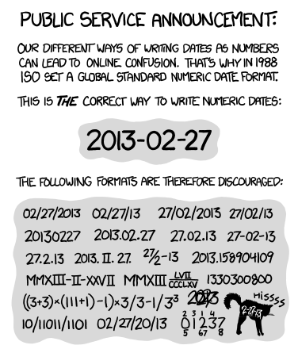

It's simple: **YYYY-MM-DD**

## dplyr - adding date *times* (code)

Dates and times are all well and good, but a *datetime* variable might be more useful.

Before we do that, we'll need to combine our dates and times together. Again, a bit of `dplyr` and some `paste` will come in handy:

```r
oyster <- oyster %>%
    mutate(start.datetime = paste(date, start.time.clean, sep = " "),
           end.datetime = paste(date, end.time.clean, sep = " "))
```

We'll need to turn these in to *datetime* variables using `lubridate`

## dplyr & lubridate - modifying fields

We've seen `dplyr` mutate being used to *add* fields to our data, but it can also *modify* them in place.

Let's combine a `mutate` with some `lubridate` functions to modify our textual datetimes in to actual datetimes:

```r
oyster <- oyster %>%
          mutate(start.datetime = dmy_hms(start.datetime),
                 end.datetime = dmy_hms(end.datetime))
```

So far so good, there's just one problem. What about dates where we touched in before midnight, but touched out afterwards? We need to add a day.

## lubridate - date manipulation

We need a way to identify those dates first. We can use the cleaned up times to do this with some simple string matching:

```r
afterMidnightSrt <- grep("00|01|02", substring(oyster$start.time,1,2))
afterMidnightEnd <- grep("00|01|02", substring(oyster$end.time,1,2))
afterMidnight <- afterMidnightEnd[!(afterMidnightEnd == afterMidnightSrt)]
```

The `substring` function extracts characters from text data. We tell it where to start extracting from, and how many characters to extract.

## lubridate - date manipulation

We then use `lubridate` to add a day:

```r
oyster[afterMidnight, "end.datetime"] <- oyster[afterMidnight, "end.datetime"] + days(1)
```

Note that dplyr was *not* used to do the manipulation for us.

Sometimes base `R` is a little more compact, but perhaps less readable if we don't know exactly what's going on.

## lubridate - date manipulation (code)

There are a few final things we might like to add to help us answer our questions:

- a journey time:

```r
oyster <- oyster %>%
          mutate(journey.time = difftime(end.datetime, start.datetime, units = "mins"))
```

- a day of the week for each journey:

```r
oyster <- oyster %>% mutate(journey.weekday = wday(date.clean,
                                                   label = TRUE,
                                                   abbr = FALSE))
```

## Answering the questions

- What are the top 5 journeys?
- **What was the longest journey, how long was it, and when was it?**
- **What is the average journey time for each day of the week?**
- **What is the average number of journeys per day of the week?**
- Where does Jim live, and what are the coordinates of the station?

Try to create the query you would need for each of these.

## Longest journey

```r
oyster %>%
    filter(journey.time == max(oyster$journey.time, na.rm = TRUE)) %>%
    select(journey.action, journey.time, date)
```

| Journey | Duration | Date |
| --- | --- | --- |
| Richmond to Catford Bridge [National Rail] | 93 mins | 25-Oct-2014 |

## Average journey time by day

```r
oyster %>%
    group_by(journey.weekday) %>%
    summarise(avg_time = floor(mean(journey.time, na.rm = TRUE)))
```

| Weekday | Average journey time |
| --- | --- |
| Monday | 46 mins |
| Tuesday | 42 mins |
| Wednesday | 39 mins |
| Thursday | 45 mins |
| Friday | 37 mins |

## Average journeys per day

```r
oyster %>%
    group_by(date.clean, journey.weekday) %>% summarise(journeys = n()) %>%
    group_by(journey.weekday) %>% summarise(avg_journeys = mean(journeys))
```

| Weekday | Average number of journeys |
| --- | --- |
| Monday | 2.134615 |
| Tuesday | 2.352941 |
| Wednesday | 2.563636 |
| Thursday | 2.065217 |
| Friday | 2.784314 |

## Wrap up

Today we have covered:

- An introduction to `dplyr` and the `%>%` pipe;
- Basic data cleansing operations with `lubridate`, `tidyr` and some string manipulations
- Simple aggregations and summaries

Next time we will look at more advanced data manipulation, data joins, and visualisation.

## Things to look at

As before, in preparation for the next session, it might be helpful/interesting (but certainly *not* essential) to read up on:

- [the basics of joining data](http://r4ds.had.co.nz/relational-data.html);
- [a nice introduction to ggplot2](http://www.statmethods.net/advgraphs/ggplot2.html);
- [leaftlet](https://rstudio.github.io/leaflet/); and
- [networkD3](https://christophergandrud.github.io/networkD3/)